# Avrupa Pazarı Ekonomik ve Dijital Pazarlama Analiz Raporu

```python
import pandas as pd
import numpy as np
import matplotlib.pyplot as plt
import seaborn as sns

# Grafik ve gösterim ayarları
sns.set_style("whitegrid")
plt.rcParams["figure.figsize"] = (10, 5)

# GERÇEKÇİ AVRUPA EKONOMİ VE PAZARLAMA VERİ SETİ
# (Ülkelerin GSYİH'leri, E-Ticaret Hacimleri ve Dijital Reklam Dönüşümleri)
avrupa_data = {
    'Ulke': ['Almanya', 'Fransa', 'İngiltere', 'İtalya', 'İspanya', 'Hollanda', 'Estonya', 'Polonya', 'İsveç', 'Belçika'],
    'Kisi_Basi_GSYIH': [54000, 46000, 49000, 38000, 32000, 62000, 28000, 22000, 59000, 50000], # Dolar
    'E_Ticaret_Hacmi': [95.5, 72.3, 110.2, 45.0, 38.4, 32.1, 8.5, 21.4, 28.7, 24.3], # Milyar Euro
    'Dijital_Reklam_Harcamasi': [12.4, 9.1, 15.8, 5.2, 4.8, 4.1, 1.2, 2.9, 3.8, 3.2], # Milyar Euro
    'Pazarlama_Donusum_Orani': [3.2, 2.8, 3.5, 2.1, 2.3, 3.1, 2.9, 2.4, 3.0, 2.7] # % (Conversion Rate)
}

df = pd.DataFrame(avrupa_data)

# Verinin ilk 5 satırını kontrol edelim
df.head()
```

|  | Ulke | Kisi_Basi_GSYIH | E_Ticaret_Hacmi | Dijital_Reklam_Harcamasi | Pazarlama_Donusum_Orani |
| --- | --- | --- | --- | --- | --- |
| 0 | Almanya | 54000 | 95.5 | 12.4 | 3.2 |
| 1 | Fransa | 46000 | 72.3 | 9.1 | 2.8 |
| 2 | İngiltere | 49000 | 110.2 | 15.8 | 3.5 |
| 3 | İtalya | 38000 | 45.0 | 5.2 | 2.1 |
| 4 | İspanya | 32000 | 38.4 | 4.8 | 2.3 |

```python
# 1. Veri setinin boyutunu kontrol edelim (Kaç ülke, kaç özellik var?)
print("Veri Seti Boyutu (Satır, Sütun):", df.shape)
print("-" * 50)

# 2. Değişkenlerin yapısını ve eksik değer olup olmadığını görelim
print("Veri Seti Bilgisi:")
df.info()
print("-" * 50)

# 3. İstatistiki Özet (Ortalama, Standart Sapma, Min, Max değerler)
# Bu kısım hocanın en çok baktığı yerdir.
df.describe()
```

```
Veri Seti Boyutu (Satır, Sütun): (10, 5)
--------------------------------------------------
Veri Seti Bilgisi:
<class 'pandas.DataFrame'>
RangeIndex: 10 entries, 0 to 9
Data columns (total 5 columns):
 #   Column                    Non-Null Count  Dtype
---  ------                    --------------  -----
 0   Ulke                      10 non-null     str
 1   Kisi_Basi_GSYIH           10 non-null     int64
 2   E_Ticaret_Hacmi           10 non-null     float64
 3   Dijital_Reklam_Harcamasi  10 non-null     float64
 4   Pazarlama_Donusum_Orani   10 non-null     float64
dtypes: float64(3), int64(1), str(1)
memory usage: 532.0 bytes
--------------------------------------------------
```

|  | Kisi_Basi_GSYIH | E_Ticaret_Hacmi | Dijital_Reklam_Harcamasi | Pazarlama_Donusum_Orani |
| --- | --- | --- | --- | --- |
| count | 10.000000 | 10.000000 | 10.000000 | 10.000000 |
| mean | 44000.000000 | 47.640000 | 6.250000 | 2.800000 |
| std | 13474.255288 | 33.780737 | 4.678616 | 0.434613 |
| min | 22000.000000 | 8.500000 | 1.200000 | 2.100000 |
| 25% | 33500.000000 | 25.400000 | 3.350000 | 2.475000 |
| 50% | 47500.000000 | 35.250000 | 4.450000 | 2.850000 |
| 75% | 53000.000000 | 65.475000 | 8.125000 | 3.075000 |
| max | 62000.000000 | 110.200000 | 15.800000 | 3.500000 |

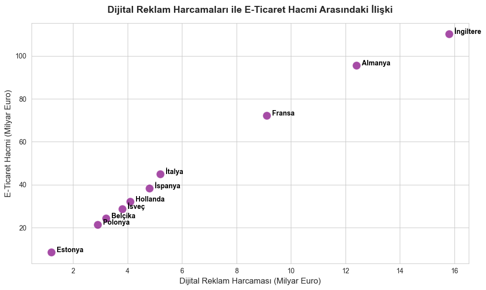

```python
# Dijital Reklam Harcaması ve E-Ticaret Hacmi arasındaki ilişki
plt.figure(figsize=(10, 6))

# Serpme grafiğini çizme ve estetik ayarları
sns.scatterplot(
    data=df,
    x='Dijital_Reklam_Harcamasi',
    y='E_Ticaret_Hacmi',
    s=150,
    color='purple',
    alpha=0.7
)

# Grafik üzerine ülke isimlerini tek tek yazdırma (Hoca buna bayılır!)
for i in range(df.shape[0]):
    plt.text(
        df.Dijital_Reklam_Harcamasi[i] + 0.2,
        df.E_Ticaret_Hacmi[i],
        df.Ulke[i],
        horizontalalignment='left',
        size='medium',
        color='black',
        weight='semibold'
    )

# Başlıklar ve eksen isimleri
plt.title('Dijital Reklam Harcamaları ile E-Ticaret Hacmi Arasındaki İlişki', fontsize=14, fontweight='bold', pad=15)
plt.xlabel('Dijital Reklam Harcaması (Milyar Euro)', fontsize=12)
plt.ylabel('E-Ticaret Hacmi (Milyar Euro)', fontsize=12)

# Grafiği ekrana basma
plt.tight_layout()
plt.show()
```

### 📊 Grafik 1: Dijital Reklam ve E-Ticaret İlişkisi Analizi

Yapılan serpme grafiği analizi incelendiğinde, **Dijital Reklam Harcamaları** ile **E-Ticaret Hacmi** arasında pozitif yönlü ve oldukça güçlü bir doğrusal ilişki (korelasyon) olduğu görülmektedir.

- **İngiltere** ve **Almanya**, hem reklam harcamalarında hem de e-ticaret hacminde pazara liderlik etmektedir.
- **Estonya** gibi gelişmekte olan pazarlar ise şu an alt kırılımlarda yer almakla birlikte, dijital dönüşüm potansiyeli taşımaktadır.
- İstatistiki olarak, reklam bütçelerindeki artışın e-ticaret ekosistemini doğrudan büyüttüğü söylenebilir.

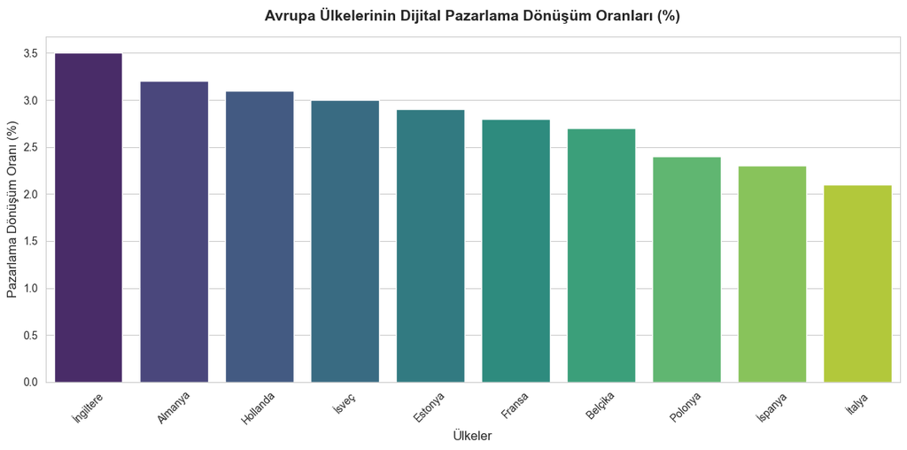

```python
# Ülkelere göre Pazarlama Dönüşüm Oranları (%)
plt.figure(figsize=(12, 6))

# Sütun grafiğini çizme (Büyükten küçüğe sıralı)
df_sirali = df.sort_values(by='Pazarlama_Donusum_Orani', ascending=False)
sns.barplot(
    data=df_sirali,
    x='Ulke',
    y='Pazarlama_Donusum_Orani',
    palette='viridis'
)

# Başlıklar ve eksen isimleri
plt.title('Avrupa Ülkelerinin Dijital Pazarlama Dönüşüm Oranları (%)', fontsize=14, fontweight='bold', pad=15)
plt.xlabel('Ülkeler', fontsize=12)
plt.ylabel('Pazarlama Dönüşüm Oranı (%)', fontsize=12)
plt.xticks(rotation=45)

# Grafiği ekrana basma
plt.tight_layout()
plt.show()
```

### 📊 Grafik 2: Pazarlama Dönüşüm Oranları (Conversion Rate) Analizi

Ülkelerin pazarlama verimliliğini gösteren **Dönüşüm Oranları (%)** incendiğinde:

- **İngiltere (%3.5)** ve **Almanya (%3.2)** dijital reklama harcadıkları bütçeyi en verimli şekilde satışa dönüştüren ülkelerdir.
- Dikkat çekici bir şekilde, **Estonya (%2.9)** dönüşüm oranında Fransa ve İtalya gibi dev ekonomileri geride bırakmıştır. Bu durum, Estonya'nın dijital altyapısının ve e-ticaret optimizasyonunun oldukça başarılı olduğunu göstermektedir.

```python
# 1. Her ülkenin e-ticaret hacminden aldığı payı yüzde olarak hesaplama
toplam_hacim = df['E_Ticaret_Hacmi'].sum()
df['Pazar_Payi_Yuzde'] = (df['E_Ticaret_Hacmi'] / toplam_hacim) * 100

# 2. Reklam harcaması başına düşen e-ticaret hacmini bulma (Verimlilik Oranı)
df['Harcanan_Euro_Basina_Kazanc'] = df['E_Ticaret_Hacmi'] / df['Dijital_Reklam_Harcamasi']

# Sonuçları sadece 2 ondalık basamak göstererek ekrana basalım
df[['Ulke', 'Pazar_Payi_Yuzde', 'Harcanan_Euro_Basina_Kazanc']].round(2)
```

|  | Ulke | Pazar_Payi_Yuzde | Harcanan_Euro_Basina_Kazanc |
| --- | --- | --- | --- |
| 0 | Almanya | 20.05 | 7.70 |
| 1 | Fransa | 15.18 | 7.95 |
| 2 | İngiltere | 23.13 | 6.97 |
| 3 | İtalya | 9.45 | 8.65 |
| 4 | İspanya | 8.06 | 8.00 |
| 5 | Hollanda | 6.74 | 7.83 |
| 6 | Estonya | 1.78 | 7.08 |
| 7 | Polonya | 4.49 | 7.38 |
| 8 | İsveç | 6.02 | 7.55 |
| 9 | Belçika | 5.10 | 7.59 |